# Testing for selection

January 08 2017

### Background

So now we need to think more closely about what DNA does. Historically, the definition of a gene was that portion of DNA that encodes a particular polypeptide, and since much of molecular population genetic theory developed in the era of protein polymorphism studies, many of the classical tests of selection involve analysis of protein coding regions. We will start by looking at a few of them; we will then move on to see how the comprehensive nucleotide polymorphism data that are available to us today allow us to broaden our scope to include all DNA sequences, coding or other.

Before we explore this question, remember that we have already explored two for departure from neutral expecations - Ewens-Watterson and the Tajima test. However, these both suffer from two shortcomings. First, they are relatively insensitive - only in the most extreme cases do the test statistics differ greatly from neutral expectations. Second, if deviation is observed, there can be multiple explanations, and the role of selection (directional or balancing) is only one of them.

### Remember the genetic code

To quickly summarize, the genetic code has the following properties:

1. It’s a triplet code - 3 nucleotides encode 1 amino acid
2. All 64 possible triplets used; 3 are terminators but 61 in fact code for amino acids
3. Thus, the code is generate - more than one codon encodes one amino acid.
4. With the exception of first position in leu, arg and ser, all of the degeneracy is in third (wobble) position.

So let’s think about evolutionary change in this context. Suppose all mutations, (synonymous or nonsynonymous) are neutral, something that we assumed when we developed the Jukes and Cantor model for estimating rates of substitutions. If so, then if we calculate d for both classes, the expectation is that they should be equal, or dN=dS.

So what do we see? First, in a sample of 16 eukaryotic genes, we find that dN=.88 and dS = 4.65. So if we compute the ratio, we get the following

```r
.88/4.65
```

```
## [1] 0.1892473
```

So what this says is simply that the number of nonsynonymous substitutions is lower than that of synonymous. Since there is no question that some substitutions will have detrimental effects on protein function, while the effect of the average syonymous one will be minimal, this result should not be suprising. What we need to do, as always, is to look for those cases in which dN/dS for a particular gene or region differs from that of protein coding regions of the genome as a whole.

To do so we can examine a case in which there is *a priori* reasons to believe that selection might be playing a role. What about in a rapidly evolving pathogen like influenza?

```r
.0025/.01
```

```
## [1] 0.25
```

And while the ratio is a bit higher than for the random sample of genes, the difference is not impressive.

There is, however, one classic case in which this simple approach was much more informative. [Hughes and Nei 1988](https://dl.dropbox.com/u/9752688/ZOO%20422P/Readings/Classics/Hughes%20and%20Nei%201988.pdf) looked at sequence variation in the MHC loci in humans. These are proteins in the immune system that are involved in antigen recognition, and much is known about their structure vis-a-vis that function. So therefore, it was possible to examine both the antigen recognition domain, likely affected by selection, and compare it with other regions not involved in that function. The basic design of the experiment was as follows:

1. Collect 12 sequences for Class 1 alleles at HLA-A,HLA-B, and HLA-C
2. Calculate mean dN and dS for all pairwise combinations by loci
3. Subdivide by Antigen recognition sites, remainder of coding region

The results can be showed as follows:

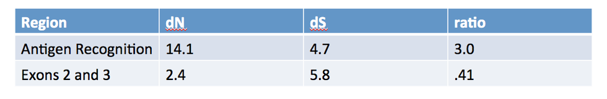

MHC

The high level of nonsynonymous substitution in the antigen-recognition region clearly suggests positive selection for amino acid substitutions, consistent with what would be expected - variation in this region provides the ability to recognize multiple antigens and thus adapt to a variable or changing pathogen environment.

### Going one step further - incorporating interspecific comparison

Up until this point, we have restricted ourselves almost exclusively to analysis of data obtained from a single species. But there is another aspect of the neutral theory we consider. As Kimura suggested in his 1971 classic paper, one way of thinking of protein polymorphsims within species is as simply a step on the path to between species differentiation. If that is the case, then if we compare dN/dS ratios among polymorphic sequences withiin a species, they should be comparable to what we observe when we make comparisons between closely related species (remembering, of course, to use a mutation model to correct for multiple hits on a single site). We will look at two tests that have been developed based on this logic, one briefly and one in some detail.

#### The HKA test

[Hudson, Kreitmand and Aguade(1987)](https://dl.dropboxusercontent.com/u/9752688/ZOO%20422P/Readings/HKA%201987.pdf) took the following approach. First, they asked what factors determine polymorphism and divergence. In brief, they are

1. Time since divergence
2. Effective population size of two species
3. The mutation and substitution rates for the gene or genes in question

And we can also note regarding these, that

1. The first two factors are population/species parameters, so they will be the same for any gene comparison we choose to make.
2. The third factor certainly does vary among genes. However, if indeed polymorphism is simply a transitional step in the divergence process, and the mutation rate is constant for a given gene, then *the ratio between variation and divergence should be the same for every gene*.

Hudson et al applied the method to data from the Alcohol dehydrogenase locus (ADH), as well as what was thought to be a noncoding flanking region, using polymorphism data from *Drosophila melanogaster* and divergence data from *D. melanogaster* and *D. sechellia*. To avoid the confounding effects of amino acid substitutions, they limited their treatment to noncoding sites. Their results were are shown below:

[figure not shown]

HKA

The statistical analysis of these results is not straightforward, however, the following points emerge:

1. Divergence between species is similar for the two genes.
2. Within-species variation (polymorphism) is much higher for Adh than for the flanking region - significant based on comparison to neutral expectations.

Hudson et al concluded that these results were consistent with the hypothesis that the Adh locus is subject to balancing selection within *D. melanogaster*, resulting in the high level of within-species polymorphism that was observed.

Note that we are assuming flanking region is neutral, and that may or may not be the case. In addition, we have restricted our consideration to noncoding substitutions, thus ignoring what we would expect to be a very important part of the picture. And finally, tests of significance involve fairly complicated simulations of neutral expectations. How can we address these problems?

#### [The McDonald-Kreitman Test](http://www.nature.com/nature/journal/v351/n6328/pdf/351652a0.pdf)

The MK test is probably the most widely used for evidence of selection in protein coding data. In essence, it combines the logic of dNdS testing with that of the HKA test, and it does so in a simple and straightforward fashion. It proceeds as follows:

1. Determine the number of silent and replacement polymorphisms within a gene and species of interest (Pn and Ps).
2. Determine the average number of substitutions (again silent and replacement) that have occurred between the species of interest and at least 1 sequence for one or more sibling species (applying JC or other correction as appropriate - Dn and Ds)
3. If indeed, as per Kimura, polymorphism is simply a stage of neutral evolution, then

Dn/Ds = Pn/Ps

The data that McDonald and Kreitman analyzed, once again for Adh, are as follows:

| Site Type | Divergent Between Species | Polymorphic Within Species |
| --- | --- | --- |
| Nonsynonymous | 7 | 2 |
| Synonymous | 17 | 42 |

Once again, polymorphism data were from *D. melanogaster*; substitution data (“fixed”) are based on comparison with two sibling species - *D. simulans* and *D. yakuba*.

So how do we go about analyzing this? Remember that what we want to know is whether the relationship of silent to replacement substitutions is the same for polymorphism within species and fixed divergence among species. In fact, we can do what is known as a contingency chi-square test to test this null hypothesis (note that McDonald and Kreitman used a G test, a more appropriate test, but which addresses the same question). In addition, we can calculate the following quantity:

FI = (Dn/Pn)/(Ds/Ps)

or alternatively

FI - (DnPs)/(DsPn)

Note that this the numerator is the divergence to polymorphism ratio for nonsynonymous changes, while the denomintor is the same for synonymous ones. We could thus imagine the following scenarios:

1. If mutation is selectively neutral, the type of mutation doesn’t matter, and FI = 1
2. If substitutions between species are adaptive, then we would expect Dn/Pn >Ds/Ps, and thus FI >1
3. In the case of heterozygote advantage within species, then (based on the second formulation) Pn >Ps, making FI <1.
4. If most nonsynonymous mutations within species are detrimental, then again, we would expect to see Pn to be small and FI >1. However, we would also expect to see an excess of low-frequency derived alleles within species, which could allow us to distinguish this from possibility 2. We will return to this point in a bit.

The function MK does the above analysis The input for it is two vectors, consisting of the rows from the table above:

```r
MK(c(7,2),c(17,42))
```

```
## $Chi.squared
##
##  Pearson's Chi-squared test
##
## data:  tbl
## X-squared = 8.3373, df = 2, p-value = 0.01547
##
##
## $FI
## [1] 8.647059
```

But remember - there are two possible explanations for a value of FI greater than one - either directional selection occurring during speciation or purifying selection within species. Which is the case here? McDonald and Kreitman argued for the former - a number of adaptive mutations occurring in the lineages of the two species that lead to an excess of nonysnonymous substitutions. They argued against the alternative hypothesis on essentially parsimony grounds, arguing that the only scenario that could lead to these results is overly complex:

1. The species was historically small, so that weakly deleterious mutations are effectively neutral and thus subject to random fixation and loss. It would be those randomly fixed mutations that result in the observed value of Dn.
2. In *D.melanogaster* at least, subsequent to speciation, there was a population expansion, such that now those weakly deleterious alleles are subject to selection and thus reduced in frequency.

To quote them, “This slightly deleterious model requires so many assumptions about selection coefficients, population sizes and times of population expansions that we prefer the simpler explanation of the occasional fixation of an adaptive mutation.”

Note that, using the G test with a correction for small sample size, a more conservative approach, McDonald and Kreitman obtained similar results. Their conclusion, explained quite well in the paper, suggest that most of the replacements that have occurred are in fact adaptive, so that nonsynonymous polymorphisms, when they occur, have a short life time.

The basic mathematics of the test is extremely simple. In fact, if we look at the MK function

```r
MK
```

```
## function(NS,SS){
##   options(warn= -1)
##   tbl <-rbind(NS,SS,correct=TRUE)
##   ch <-chisq.test(tbl)
##   FI <-((NS[1]/NS[2])/(SS[1]/SS[2]))
##   list(Chi.squared=ch,FI=FI)
## }
## <environment: namespace:TeachingPopGen>
```

We see that it is little more than a call to the built-in function chisq.test. In addition, there are web sites that will do the calculation interactively - for example see [this one](http://turner.faculty.swau.edu/mathematics/math241/materials/contablecalc/entry.php).

### Summary

So we’ve seen that we can take three different approaches to the detection of selection, all of which involve, one way or another, a comparison of substitution rates and levels of polymorphism. Note, however, that, as described so far, we are, by and large, approaching the problem on a gene-by-gene basis. Ideally, we’d like to take a broader view, using available data to assess patterns of selection in the genome as a whole. In our next unit, we will begin to do that, using the MK statistic as a means to look for evidence of selection in the *Drosophila* genome.

### Aggregating the data

The simplest place to start is to simply look at numbers of polymorphisms and fixed differences in the genomes as a whole, applying the MK function to the data as a whole:

```r
MK(c(2307,465),c(6286,2411))
```

```
## $Chi.squared
##
##  Pearson's Chi-squared test
##
## data:  tbl
## X-squared = 134.73, df = 2, p-value < 2.2e-16
##
##
## $FI
## [1] 1.902907
```

### The Problem of Pooling

#### A Hypothetical Example

But is pooling acrpss loci appropriate? [Shapiro et al 2007](http://www.pnas.org/content/104/7/2271.full.pdf) - explains this rather well - if all genes have same genealogy and do not recombine, then pooling makes sense. If not, however, problems arise. For example, consider the hypothetical case they give in their Figure 2:

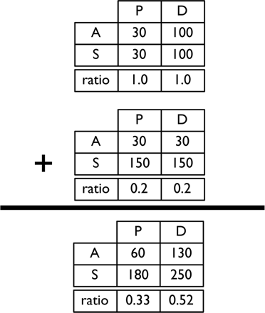

Shapiro2

We can do an MK test on the combined numbers as follows:

```r
MK(c(130,250),c(60,180))
```

```
## $Chi.squared
##
##  Pearson's Chi-squared test
##
## data:  tbl
## X-squared = 6.2156, df = 2, p-value = 0.0447
##
##
## $FI
## [1] 1.56
```

And we get a significant result, with FI>1, implying (as in the case of the Adh example) that there may have been positive selection giving rise to substitutions. We know, however, that this is actually an artifact, due to the fact that the second locus is more constrained with respect to divergence (total substitutions=200 vs. 180) but more polymorphic (180 vs. 60). Thus, there is a negative correlation between A/S and P/D. So what we need to do is the following:

1. Generate an expected distribution of FI, based on the overall observed numbers
2. Calculate FI on a gene by gene basis for the actual data set and determine the mean
3. Compare the observed average with that which is expected.

#### The Expected Distribution of the Pooled FI

First, let’s create a matrix of the overall observations

```r
N <-c(465,2307)
S <-(c(2411,6286))
Obs <-rbind(N,S)
NS <-rowSums(Obs)
Obs <-cbind(Obs,NS)
PD <-colSums(Obs)
Obs <-rbind(Obs,PD)
rownames(Obs) <-c("Nonsynonymous","Synonymous","Total")
colnames(Obs) <- c("Polymorphism","Divergence","Total")
Obs
```

```
##               Polymorphism Divergence Total
## Nonsynonymous          465       2307  2772
## Synonymous            2411       6286  8697
## Total                 2876       8593 11469
```

Now what we’ll do is to generate 1000 simulated data sets, in which we hold the P/D and dN/dS ratios to what was in the observed data. First, we need to load a couple of functions

```r
#calculate the FI for a given set of data
FI <-function(x){
  (x[1,2]/x[2,2])/(x[1,1]/x[2,1])
}
```

```r
#Generate 1000 random data sets with row and column totals equal to observed data
boot <- function (Obs,n=1000) r2dtable(n,rowSums(Obs),colSums(Obs))
```

Now we will generate our random data sets

```r
all.boot <-boot(Obs[1:2,1:2])
head(all.boot)
```

```
## [[1]]
##      [,1] [,2]
## [1,]  649 2123
## [2,] 2227 6470
##
## [[2]]
##      [,1] [,2]
## [1,]  708 2064
## [2,] 2168 6529
##
## [[3]]
##      [,1] [,2]
## [1,]  687 2085
## [2,] 2189 6508
##
## [[4]]
##      [,1] [,2]
## [1,]  718 2054
## [2,] 2158 6539
##
## [[5]]
##      [,1] [,2]
## [1,]  744 2028
## [2,] 2132 6565
##
## [[6]]
##      [,1] [,2]
## [1,]  722 2050
## [2,] 2154 6543
```

and look at the expected distribution of FI values in these simulated data

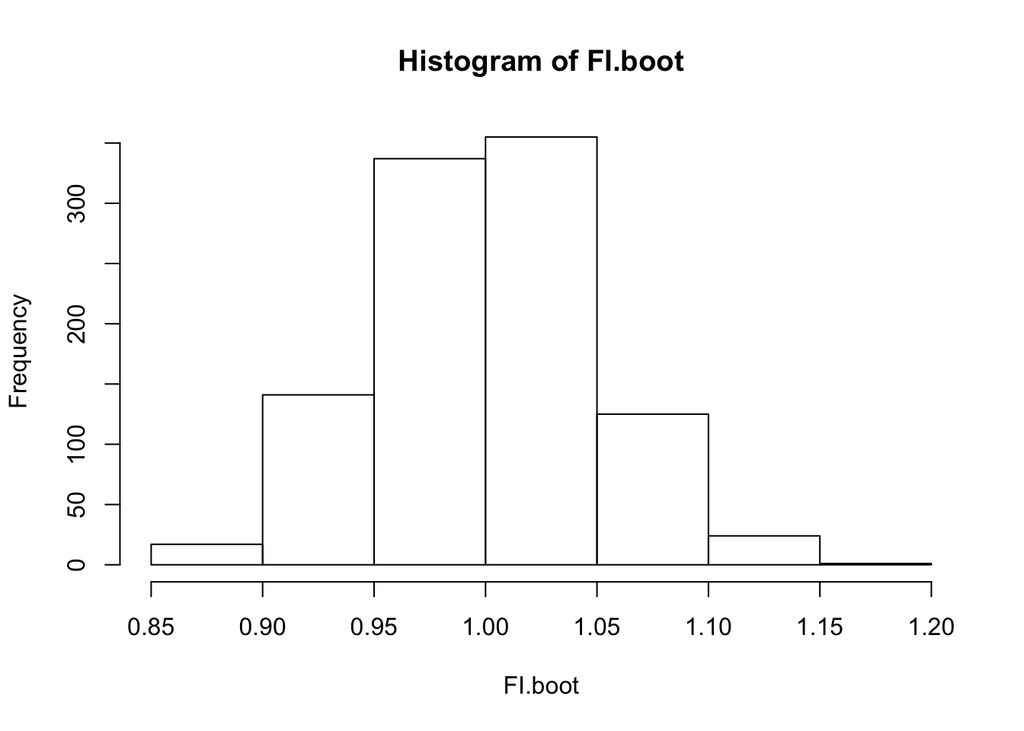

```r
FI.boot <-sapply(all.boot, FI)
hist(FI.boot)
```

```r
mean(FI.boot)
```

```
## [1] 1.000728
```

### Analysis of Locus Data

#### Constraint and divergence

So is there heterogeneity in the data? Consider the following factors that will affect the quantities we’ve been talking about.

1. Constraint - limit (due to selection) on permissible substitutions - if high, the ratio of nonsynonymous to synonymous differences (totalling polymorphism and divergence) should be low.
2. Genealogy - do all genes have same historical topology? In other words, do all genes have the same TMRCA? This would be the case in the absence of recombination, but of course nuclear genes do recombine. And most importantly, *alleles with recent common ancestors should have lower levels of polymorphism than those with older ones*.

Thus, we can think of the ratio of nonsysnymous to synonymous substitutions as a measure of constraint, and the number of polymorphic sites (total) relative to divergent ones as a reflection of gene geneaology. Now are question is, are these ratios independent of one another in the data?

So the question becomes, is there indeed a relationship of P/D vs A/S? To do so, we’ll look at the complete data set from Shapiro et al - 419 loci from D melanogaster and D. simulans

```r
data(Shapiro) # Loads a slightly revised version of Shapiro et al. supplemental table 4

attach(shap.dat)
```

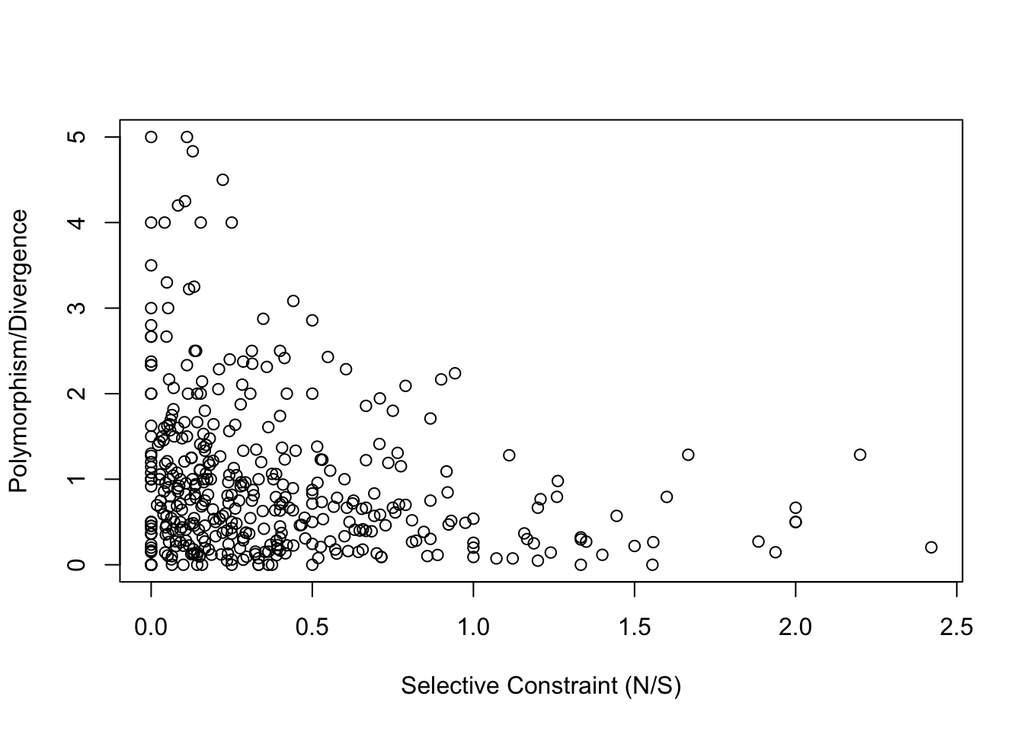

```r
ratio.PD <-(Ps+Pn)/(Ds+Dn)
ratio.NS <-(Dn+Pn)/(Ds+Ps)
plot(ratio.NS, ratio.PD,ylim =c(0,5),xlab="Selective Constraint (N/S)",ylab="Polymorphism/Divergence")
```

How significant is the relation? Following a little cleanup (code not shown) we can quantify

```
## [1] -0.1882209
```

And with that, we can fit a regression to the data

```r
reg <-lm(ratio.PD~ratio.NS)
summary(reg)
```

```
##
## Call:
## lm(formula = ratio.PD ~ ratio.NS)
##
## Residuals:
##     Min      1Q  Median      3Q     Max
## -1.3540 -0.7713 -0.2907  0.2562 17.6827
##
## Coefficients:
##             Estimate Std. Error t value Pr(>|t|)
## (Intercept)  1.35398    0.09829  13.775  < 2e-16 ***
## ratio.NS    -0.69633    0.17879  -3.895 0.000115 ***
## ---
## Signif. codes:  0 '***' 0.001 '**' 0.01 '*' 0.05 '.' 0.1 ' ' 1
##
## Residual standard error: 1.49 on 413 degrees of freedom
## Multiple R-squared:  0.03543,    Adjusted R-squared:  0.03309
## F-statistic: 15.17 on 1 and 413 DF,  p-value: 0.0001146
```

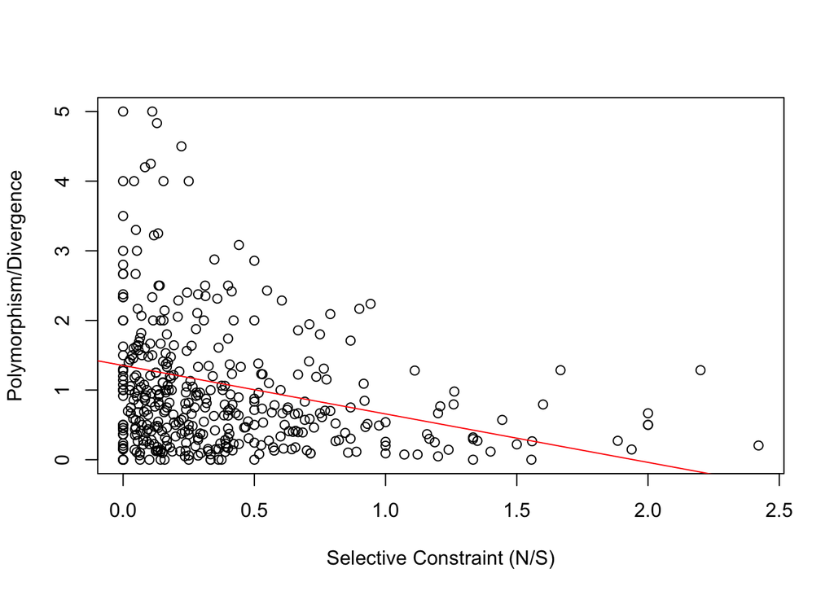

```r
plot(ratio.NS, ratio.PD,ylim =c(0,5),xlab="Selective Constraint (N/S)",ylab="Polymorphism/Divergence")
abline(reg,col="red")
```

```r
#abline(a=reg$coefficients[1],b=reg$coefficients[2],col="darkred")
```

What we see is that indeed the more constrained loci (with low values of N/S) do indeed tend to be more polymorphic, relative to their total divergence.

#### Analyzing a random gene

Thus, what we need to do is to take a gene-by-gene approach to calculate expectations for FI; we can then compare the mean of the observed values to that of the expectations. As an example, we’ll repeat out FI and bootstrapping procedures for one random locus (number 8 in the original data set)

```r
dat.vec <-shap.dat[8,]
dat.vec
```

```
##         Locus Ds Dn  X Ps Pn hPs hPn FI.All FI.High        pAll
## 8 FBgn0040060  8 22 NA 11  0   5   0  26.89   12.22 2.39224e-05
##         pHigh Ka.Ks    Ka   Ks Rec..cM.Mb.
## 8 0.003964489 0.711 0.042 0.06        4.97
```

```r
Obs <-rbind(c(dat.vec$Pn+1,dat.vec$Dn),c(dat.vec$Ps,dat.vec$Ds+1))
Obs
```

```
##      [,1] [,2]
## [1,]    1   22
## [2,]   11    9
```

```r
FI(Obs)
```

```
## [1] 26.88889
```

Note that we added one to Pn and Ds to avoid division by zero errors. The FI for this locus is obviously exceedingly high, but what should we be comparing it against? We can repeat the bootstrap procedure with these data

```r
boot.8 <-boot(Obs)
```

and apply FI to the results

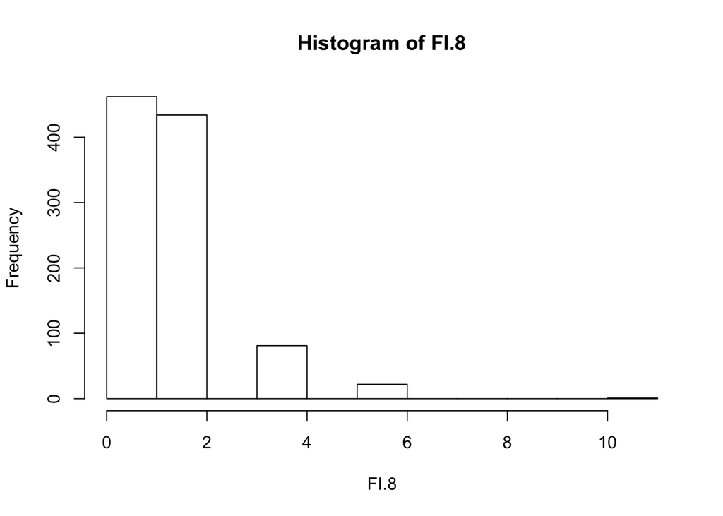

```r
FI.8 <-sapply (boot.8,FI)
hist(FI.8)
```

```r
mean(FI.8)
```

```
## [1] 1.315503
```

So in this particular case, while the expected value for the locus does differ from 1, the observed value is much, much higher. However, when we average over all loci, we get a mean observed FI of 1.18 and a mean expected value of 1.25. Thus what appears initially to be a higher than expected value turns out to be lower.

### Further refinements

Shapiro et al make three additional points that are are worth summarizing:

Because we are dealing with multiple species, it is possible, in most cases of polymorphisms within *D. melanogaster*, to infer ancestral and derived alleles. We can then ask how FI is related to the frequency of the derived allele, with the goal of asking whether there is evidence of positive selection acting on derived alleles or negative selection acting to prevent divergence.

#### Negative Selection

Here, the logic is that a derived allele with low frequency is likely to be the target of negative selection, keeping its frequency low. To address this, they divided the data into frequency classes of the derived allele and looked at the distribution of Pn/Ps (A/S in their notation) among those classes:

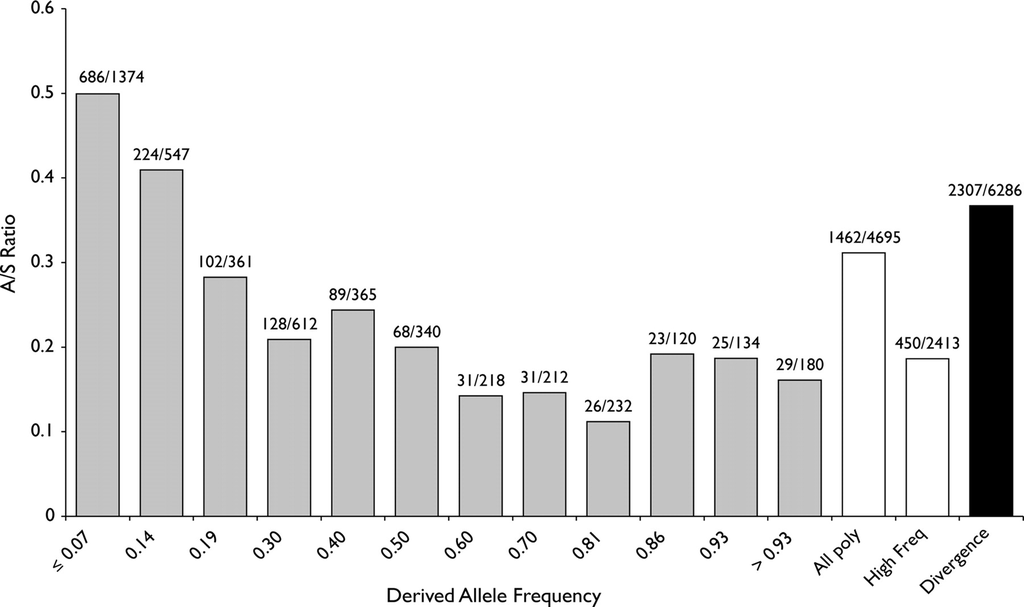

Shapiro4

Note that the first three columns (derived alleles with 1, 2, and 3 copies in the sample) have N/S polymorphism levels higher than the rest, suggesting that, there is a lower level of nonsynonymous polymorphism relative to synonymous because of purifying selection acting against these alleles. based on this, we can first calculate the total ratios for these two classes:

```r
as.tot <-1462/4695
as.high <-450/2413
```

We can then use the normalized differences between the two to estimate the fraction of all nonsynonymous sites with deleterious nonsynonymous alleles as follows.

```r
f.del <-(as.tot-as.high)/as.tot
f.del
```

```
## [1] 0.401115
```

#### Positive Selection

So about 40% of polymorphism are deleterious. What about positive selection? How many of the substitutions that have occurred are adaptive? Here, we can focus on the high frequency sites and compare levels of polymorphism with levels of divergence. We’ve already done the above calculation (as.high above, with a value of 0.1864898) From the data, we also know, for the same sites, the dNdS ratio:

```r
p.high =465/2411
d.high <-  2307/6286
p.high;d.high
```

```
## [1] 0.192866
```

```
## [1] 0.367006
```

So what we need to do is to determine how much higher, on average, FI is in the data compared with the expectation. To do so, we can bootstrap the high frequency data to get an expectation, and then compare it with the value we calculated, just as we did above for the total data set. When the authors did so, they obtained the following:

```r
FI.obs <-1.97
FI.exp <-1.40
ns.pos <-(FI.obs-FI.exp)/FI.obs
ns.pos
```

```
## [1] 0.2893401
```

#### Selection and Recombination Rates

Finally, Shapiro et al. considered how these patterns are affected by recombination rates. The logic for doing so is as follows (and we will develop this more fully in the future). Consider how selection on one locus could affect variation at a linked neutral one:

1. If selection is positive, then it would tend to increase the frequency of whatever neutral variants are linked to the selected allele, leading to what we call a “selective sweep”
2. If it is negative, then elimination of the detrimental allele would also remove variation at neighboring sites. This is referred to as “Background selection”.

Discriminating between these two possibilities is difficult. However, Shapiro et al divided their data into those genes that occur in regions with normal levels of recombination and those in recombinationally constrained regions, and doing a quick test of the aggregated data (using only the high frequency polymorphic sites, thus ignoring those likely to be ones with weakly detrimental alleles):

```r
high.r <-MK(c(1315,297),c(3442,1883)) #MK for high recomb rate; high frequency sites
low.r <-MK(c(  992,152),c(2844,528))
high.r$FI; low.r$FI
```

```
## [1] 2.422193
```

```
## [1] 1.211637
```

We see that the signal of positive selection is much greater in the case of the high recombination regions than in the low.

### Conclusions

It is well worth taking some time to read this paper and understand the logic that underlies it. It constitutes a very nice demonstration about how logic developed based on single-gene analysis can be applied at the genomic level. We shall see that, in more recent years, as genomic data have become increasingly available, more sophisticated analytical approaches have been developed and applied. Nevertheless, the MacDonald-Krietman test remains a staple of population genetics, and the analysis we have just walked through remains a paradigm.